# Final Report

Isaac Slagel and Jack Welsh

## Introduction

According to an ASPCA estimate, over 6.5 millions animals enter a shelter system every year. (Cite 1). After entering the shelter system animals are either rehabilitated and sent to homes or euthanized. Animal shelters, while running mostly on revenue from donations and adoption fees, routinely run into perminant defieciets and must be supported with money from local governments (Cite 2). Knowing more about the outcomes of animals from these shelters could help us minimize the percent of animals that need to be euthanized. Further, by identifying which animals are less likely to be adopted, we can help shelters allocate resources to minimize the time these animals spend in the shelter system.

Our research looks into animal shelters in the Dallas area using a dataset provided by the city of Dallas on dallasopendata.com. This data includes information about every animal that has been brought into an animal shelter in the Dallas area. There are 61634 individual animals in this dataset with with information about when and where the animal was found, the health of the animal on arrival, and whether the animal was adopted, euthinized or transfered.

Recent research on animal shelters have consistantly shown that outcomes for pitbulls are consistantly worse than other dog breeds (Patronek & Crowe 2018, Lepper et al 2002). We are interested in seeing if these this trends exist in the Dallas animal shelter system.

## Materials and Methods

In order to fit a binomial regression, we had to summarise our dataset with respect to certain variables we controlled for in our model. One interesting issue that we encountered was the significance of the dataset we fit on SE estimates. If we summarized our data for each specific model, parameter estimates had increased SEs and more insignificant p-values. However, if we fit all of our models on the same, more extensive, summary table, SEs were small and parameters were more likely to be significant. We decided to proceed with the latter option, as it allows us to carry out nested F tests and would be more like a modeling process for true grouped data. This could mean that our SEs are artifically low.

We used binomial regression to compare how the outcomes of pitbulls differ from other breeds of dog. In fitting this model we had to control for a plethora of cofounding variables including season of outcome, chip status, and intake condition of the animal. We also considered a multilevel model to account for difference in district correlation. Next we used a binomial regression to compare how the outcomes of dogs and cats differ, after controlling for season of outcome, chip status, and intake condition of the animal. We used findings from our exploratory data analysis to guide decisions on variable selection. Additionally we refered to models fit in the literature to guide decisions about model inclusion.

We also fit multilevel logistic regression models to compare ourcomes after accounting for correlation within city council districts. Our modeling process took on a similar approach to the binomial regression, we examined differences in odds of dying for pitbulls and non-pitbulls after accounting for differences in chip status, and season.

To investigate the ammount of time that dogs are spending in the animal shelter before dying we used cox proportional hazards. Cox proportional hazards is a semi parametric model used in survival to analyze how variables of interest affect the time till an event occuring. As the name suggests this is commonly used to investigate what factors affect time till death. This is done by comparing hazard rates using a hazard ratio. The hazard ratio is the ratio of hazard rates between groups, a hazard rate is the rate at which the outcome is happening. So, this type of model investigates how variables affect the rate at which outcomes happen.

The cox proportional hazards model is a semiparametric model, this means that this model does not make assumptions about the underlying distribution of data, but it does assume that the hazard ratios for any two individuals is constant over time. In other words, the risk of the outcome of interest happening for one individual at every time point must be proportionally constant to all other individuals.

This model follows the general form

$$h(t)=h_0(t)*e^{b_1*x_1+b_2*x_2+....+b_p*x_p}$$
.

where $h_0(t)$ is called the baseline hazard rate and is an estimation of the hazard rate of an individual at time t with $x_1$ to $x_p$ all equal to 0 having the outcome of interest already happened. $b_1$ to $b_p$ are the hazard ratio estimates. These are estimations of how much the hazard rate will change at time t compared to the baseline hazard rate at time t. This model also allows us to censor our data. Censoring is when everything that is not the outcome is labled as censored. This is nice because if an individual transferes to a different animal shelter we can still include this animal even though we dont know what happend to it. We know that till time t the animal was ok, but after time t it is no longer part of our analysis. This allows us to include all outcome possibilities for our analysis.

## Results

#### EDA Results: Effect of Council District

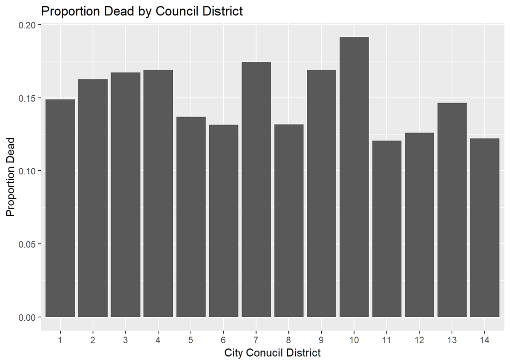

#### EDA Results: Time Till Death for Dogs

When invesitgating the ammoint of time that dogs spend in the animal shelter before dying or having another outcome we noticed that pitbulls as mentioned before die much more often, but the probability of surviving decreases faster for pitbulls than for non pitbulls.

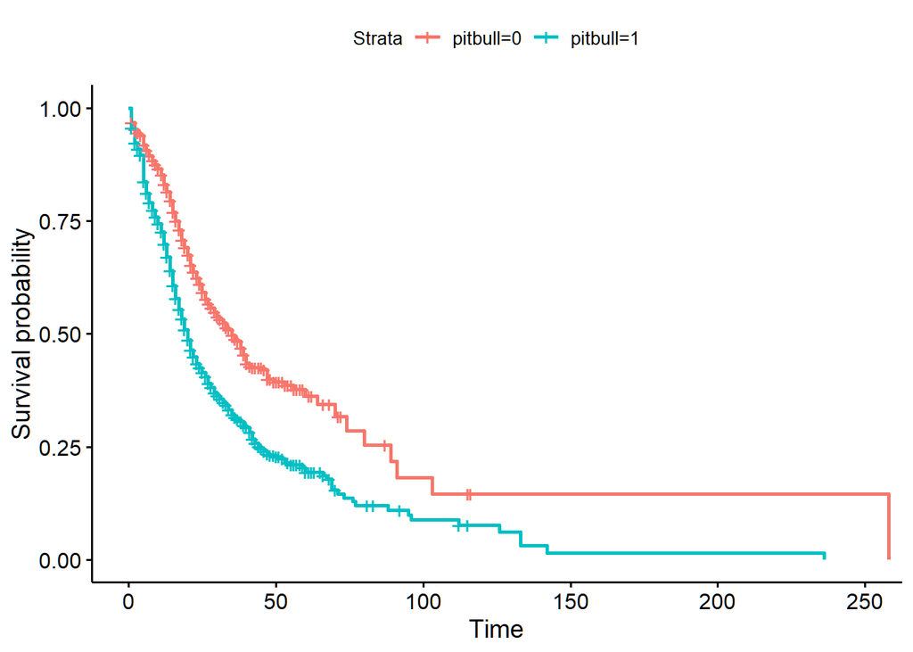

#### Multilevel Model for Dog Outcomes

During our EDA we found that there was a difference in deaths between city council districts this made us suspect that the guidelines within each city coucil district might be different and that there might be correlation within city council district. To account for this potential correlation we used a multilevel logistic regression model.

Our model has two levels,

- Level 1

$$log(\frac{p_{ij}}{1-p_{ij}})=a_i+b_i*summer_{ij}+c_i*pitbull_{ij}+d_i*chipstatus_{ij}$$

- Level 2
  $$\begin{eqnarray*}
  a_i&=\alpha_0+u_i\\
  b_i&=\beta_0+v_i\\
  c_i&=\gamma_0+w_i\\
  d_i&=\delta_0+x_i.
  \end{eqnarray*}$$

The variance components are described by:

$$\begin{bmatrix} u_i \\ v_i \\ w_i\\ x_i \end{bmatrix}=N\begin{pmatrix} \begin{bmatrix} 0 \\ 0 \\ 0 \\ 0 \end{bmatrix}, \begin{bmatrix} \sigma_u^2 & & & \\ \sigma_{uv} & \sigma_v^2 & & \\ \sigma_{uvw} &\sigma_{vw} & \sigma_w^2 & \\ \sigma_{uvwx} & \sigma{vwx} & \sigma_{wx} & \sigma_x^2 \end{bmatrix} \end{pmatrix}$$

#### Modeling Dog and Cat Differences

In our modeling of Dog and Cat differences we used used binomial regression. To model this we considered the following model:

$$log(\frac{p_{i}}{1-p_{i}})=\beta_0+\beta_1 DogYN + \beta_i(Confounder_i)$$

#### Modeling Time Till Death for Pitbulls

We approached this task by using cox proportional hazards. We wanted to control for chip_status and summer, but the proportional hazards assumption was no longer met when we added these confounding variables to our model. To get around this, we subset our data into 4 smaller datasets, one where it was the summer and all the animals had a chip, one where it was not the summer and all the animals had chips, one where it was summer and none of the animals had chips, and one where it was not the summer and the animals did not have chips. For each of our 4 datasets we fit the following model:

$$h(t)=h_0(t)*e^{b_1*Pitbull}$$
.

We found that in all 4 subsets of the data the coefficient for pitbull is significant. The hazard ratio ranged from 1.69 in the subset where it is not the summer and all the animals have chips to 1.94 in the not summer and all animals do not have a chip dataset. In laymens terms this means that on average at any time during an animals stay at the animal shelter 1.69 to 1.94 times as many pitbulls have died as non pitbulls.

## Discussion

Conclusions about animal outcomes of animals in shelters from this report can only be extended to the city of Dallas. While our sample size is totally representative for this population, we cannot account for differences that would be encountered in other municipalities, say higher adoption rates or less stigma against certain breeds of dog. Further, we cannot be sure that the trends observed in this paper will continue into the future. Anti-pitbull advocacy groups like [National Pitbull Victims Awareness](https://www.nationalpitbullvictimawareness.org/) and pro-pitbull advocacy groups like [Love-a-Bull](http://love-a-bull.org/resources/statistics-pit-bull-bites-community-safety/) are at odds trying to sway public opinion and policy reguarding the handling of pitbulls in animal shelters. If changes in public percecption of pitbulls or the policy that surrounds them changes, our model will lose it’s generalizability to Dallas.

One limitation of our study is that we do not know what happens to animals after they have been transferred out of the animal shelter. In our analysis we have viewed this outcome as a live outcome, but for all we know these animals could go on to another shelter where they are euthanized. Depending on the validity of our assumption, we could be adding some bias to our conclusions. Additionally, there is not consistant infomration on the criteria used by shelters to evaluate animals intake conditions. We look for key words that indicated the health of the animal. However we are not sure how consistant these evaluations are across all Dallas animal shelters.

Future work could be done in Dallas to help minimize the number of animals which need to be euthanized. By identifying specific at-risk groups of animals, more resources could be allocated to advocating for these animals or transfering them to other No-Kill shelters. We would recomend any additional research to work directly with the Dallas Animal Shelter group. By having a direct contact with the group doing data collection, a statistician will be able to better identify pressing issues of the group and verify certain assumptions that we have not been able to verify.

# Works Cited

1. https://www.aspca.org/animal-homelessness/shelter-intake-and-surrender
2. https://rucore.libraries.rutgers.edu/rutgers-lib/38418/PDF/1/play/

Patronek, G. J., & Crowe, A. (2018). Factors Associated with High Live Release for Dogs at a Large, Open-Admission, Municipal Shelter. Animals : an open access journal from MDPI, 8(4), 45. doi:10.3390/ani8040045

[Lepper, M., Kass, P. H., & Hart, L. A. (2002). Prediction of adoption versus euthanasia among dogs and cats in a California animal shelter. Journal of Applied Animal Welfare Science, 5(1), 29-42.](https://www.tandfonline.com/doi/abs/10.1207/S15327604JAWS0501_3)

[Posage, J. M., Bartlett, P. C., & Thomas, D. K. (1998). Determining factors for successful adoption of dogs from an animal shelter. Journal of the American Veterinary Medical Association, 213(4), 478-482.](https://europepmc.org/abstract/med/9713528)

[Lampe, R., & Witte, T. H. (2015). Speed of dog adoption: Impact of online photo traits. Journal of applied animal welfare science, 18(4), 343-354.](https://www.tandfonline.com/doi/abs/10.1080/10888705.2014.982796)

### Dogs vs Cats

```r
cat_dog_binom <- adoptions %>%
  filter(!str_detect(intake_subtype, "(DEAD)|(DIED)")) %>%
  filter(dog == 1 | cat == 1) %>%
  mutate(out_dead = outcome_type %in% c("DEAD ON ARRIVAL", "EUTHANIZED", "DIED"),
         summer = ifelse(month %in% c(5, 6, 7, 8, 9), 1, 0))%>%
  mutate(chip_status = ifelse(chip_status=="SCAN CHIP", 1, 0)) %>%
  group_by(dog, chip_status, summer, stray) %>%
  summarize(prop_dead = sum(out_dead)/n(), count = n())

####### MODEL 1: dog #########

dogcat_model1_binom <- glm(prop_dead ~ dog, weights = count, family = binomial, data = cat_dog_binom)

dogcat_model1_quasi <- glm(prop_dead ~ dog, weights = count, family = quasibinomial, data = cat_dog_binom)

summary(dogcat_model1_binom)
```

```
##
## Call:
## glm(formula = prop_dead ~ dog, family = binomial, data = cat_dog_binom,
##     weights = count)
##
## Deviance Residuals:
##     Min       1Q   Median       3Q      Max
## -19.837   -7.385   -2.250    4.985   15.639
##
## Coefficients:
##             Estimate Std. Error z value Pr(>|z|)
## (Intercept) -1.43741    0.02199  -65.38   <2e-16 ***
## dog         -0.30509    0.02563  -11.90   <2e-16 ***
## ---
## Signif. codes:  0 '***' 0.001 '**' 0.01 '*' 0.05 '.' 0.1 ' ' 1
##
## (Dispersion parameter for binomial family taken to be 1)
##
##     Null deviance: 1883.0  on 17  degrees of freedom
## Residual deviance: 1745.6  on 16  degrees of freedom
## AIC: 1866
##
## Number of Fisher Scoring iterations: 4
```

```r
exp(confint(dogcat_model1_binom))
```

```
##                 2.5 %    97.5 %
## (Intercept) 0.2274800 0.2479563
## dog         0.7010303 0.7751213
```

```r
summary(dogcat_model1_quasi)
```

```
##
## Call:
## glm(formula = prop_dead ~ dog, family = quasibinomial, data = cat_dog_binom,
##     weights = count)
##
## Deviance Residuals:
##     Min       1Q   Median       3Q      Max
## -19.837   -7.385   -2.250    4.985   15.639
##
## Coefficients:
##             Estimate Std. Error t value Pr(>|t|)
## (Intercept)  -1.4374     0.2249  -6.393 8.91e-06 ***
## dog          -0.3051     0.2621  -1.164    0.261
## ---
## Signif. codes:  0 '***' 0.001 '**' 0.01 '*' 0.05 '.' 0.1 ' ' 1
##
## (Dispersion parameter for quasibinomial family taken to be 104.5899)
##
##     Null deviance: 1883.0  on 17  degrees of freedom
## Residual deviance: 1745.6  on 16  degrees of freedom
## AIC: NA
##
## Number of Fisher Scoring iterations: 4
```

```r
exp(confint(dogcat_model1_quasi))
```

```
##                 2.5 %    97.5 %
## (Intercept) 0.1495373 0.3624932
## dog         0.4457027 1.2501118
```

```r
####### MODEL 2: dog + summer #########

dogcat_model2_binom <- glm(prop_dead ~ dog + summer, weights = count, family = binomial, data = cat_dog_binom)

dogcat_model2_quasi <- glm(prop_dead ~ dog + summer, weights = count, family = quasibinomial, data = cat_dog_binom)

summary(dogcat_model2_binom)
```

```
##
## Call:
## glm(formula = prop_dead ~ dog + summer, family = binomial, data = cat_dog_binom,
##     weights = count)
##
## Deviance Residuals:
##     Min       1Q   Median       3Q      Max
## -17.003   -6.915   -5.412    5.530   19.155
##
## Coefficients:
##             Estimate Std. Error z value Pr(>|z|)
## (Intercept) -1.61541    0.02452 -65.870   <2e-16 ***
## dog         -0.24951    0.02590  -9.632   <2e-16 ***
## summer       0.42766    0.02392  17.879   <2e-16 ***
## ---
## Signif. codes:  0 '***' 0.001 '**' 0.01 '*' 0.05 '.' 0.1 ' ' 1
##
## (Dispersion parameter for binomial family taken to be 1)
##
##     Null deviance: 1883.0  on 17  degrees of freedom
## Residual deviance: 1434.4  on 15  degrees of freedom
## AIC: 1556.8
##
## Number of Fisher Scoring iterations: 4
```

```r
exp(confint(dogcat_model2_binom))
```

```
##                 2.5 %    97.5 %
## (Intercept) 0.1894425 0.2085590
## dog         0.7407010 0.8198698
## summer      1.4633398 1.6071906
```

```r
summary(dogcat_model2_quasi)
```

```
##
## Call:
## glm(formula = prop_dead ~ dog + summer, family = quasibinomial,
##     data = cat_dog_binom, weights = count)
##
## Deviance Residuals:
##     Min       1Q   Median       3Q      Max
## -17.003   -6.915   -5.412    5.530   19.155
##
## Coefficients:
##             Estimate Std. Error t value Pr(>|t|)
## (Intercept)  -1.6154     0.2344  -6.892 5.13e-06 ***
## dog          -0.2495     0.2476  -1.008    0.330
## summer        0.4277     0.2286   1.871    0.081 .
## ---
## Signif. codes:  0 '***' 0.001 '**' 0.01 '*' 0.05 '.' 0.1 ' ' 1
##
## (Dispersion parameter for quasibinomial family taken to be 91.33309)
##
##     Null deviance: 1883.0  on 17  degrees of freedom
## Residual deviance: 1434.4  on 15  degrees of freedom
## AIC: NA
##
## Number of Fisher Scoring iterations: 4
```

```r
exp(confint(dogcat_model2_quasi))
```

```
##                 2.5 %    97.5 %
## (Intercept) 0.1232172 0.3096656
## dog         0.4842912 1.2820599
## summer      0.9734565 2.3902024
```

```r
####### MODEL 3: dog + chip ######

dogcat_model3_binom <- glm(prop_dead ~ dog + chip_status, weights = count, family = binomial, data = cat_dog_binom)

dogcat_model3_quasi <- glm(prop_dead ~ dog + chip_status, weights = count, family = quasibinomial, data = cat_dog_binom)

summary(dogcat_model3_binom)
```

```
##
## Call:
## glm(formula = prop_dead ~ dog + chip_status, family = binomial,
##     data = cat_dog_binom, weights = count)
##
## Deviance Residuals:
##      Min        1Q    Median        3Q       Max
## -15.6677   -4.1391    0.1846   10.8318   14.4792
##
## Coefficients:
##             Estimate Std. Error z value Pr(>|z|)
## (Intercept) -1.40636    0.02211 -63.599   <2e-16 ***
## dog         -0.24565    0.02620  -9.377   <2e-16 ***
## chip_status -0.29305    0.02828 -10.363   <2e-16 ***
## ---
## Signif. codes:  0 '***' 0.001 '**' 0.01 '*' 0.05 '.' 0.1 ' ' 1
##
## (Dispersion parameter for binomial family taken to be 1)
##
##     Null deviance: 1750.8  on 15  degrees of freedom
## Residual deviance: 1503.0  on 13  degrees of freedom
##   (2 observations deleted due to missingness)
## AIC: 1625.4
##
## Number of Fisher Scoring iterations: 4
```

```r
exp(confint(dogcat_model3_binom))
```

```
##                 2.5 %    97.5 %
## (Intercept) 0.2345951 0.2558385
## dog         0.7431337 0.8235017
## chip_status 0.7056151 0.7883420
```

```r
summary(dogcat_model3_quasi)
```

```
##
## Call:
## glm(formula = prop_dead ~ dog + chip_status, family = quasibinomial,
##     data = cat_dog_binom, weights = count)
##
## Deviance Residuals:
##      Min        1Q    Median        3Q       Max
## -15.6677   -4.1391    0.1846   10.8318   14.4792
##
## Coefficients:
##             Estimate Std. Error t value Pr(>|t|)
## (Intercept)  -1.4064     0.2391  -5.883 5.38e-05 ***
## dog          -0.2456     0.2832  -0.867    0.401
## chip_status  -0.2931     0.3057  -0.959    0.355
## ---
## Signif. codes:  0 '***' 0.001 '**' 0.01 '*' 0.05 '.' 0.1 ' ' 1
##
## (Dispersion parameter for quasibinomial family taken to be 116.867)
##
##     Null deviance: 1750.8  on 15  degrees of freedom
## Residual deviance: 1503.0  on 13  degrees of freedom
##   (2 observations deleted due to missingness)
## AIC: NA
##
## Number of Fisher Scoring iterations: 4
```

```r
exp(confint(dogcat_model3_quasi))
```

```
##                 2.5 %    97.5 %
## (Intercept) 0.1496550 0.3838132
## dog         0.4540004 1.3839138
## chip_status 0.3987708 1.3312323
```

```r
####### MODEL 4: summer + dog + summer:dog ######

dogcat_model4_binom <- glm(prop_dead ~ summer+dog+ summer:dog, weights = count, family = binomial, data = cat_dog_binom)

dogcat_model4_quasi <- glm(prop_dead ~ summer+dog+ summer:dog, weights = count, family = quasibinomial, data = cat_dog_binom)

summary(dogcat_model4_binom)
```

```
##
## Call:
## glm(formula = prop_dead ~ summer + dog + summer:dog, family = binomial,
##     data = cat_dog_binom, weights = count)
##
## Deviance Residuals:
##     Min       1Q   Median       3Q      Max
## -17.392   -7.749   -4.789    6.527   18.670
##
## Coefficients:
##             Estimate Std. Error z value Pr(>|z|)
## (Intercept) -1.67600    0.03030 -55.313  < 2e-16 ***
## summer       0.56018    0.04434  12.634  < 2e-16 ***
## dog         -0.17185    0.03420  -5.024 5.05e-07 ***
## summer:dog  -0.18718    0.05275  -3.549 0.000387 ***
## ---
## Signif. codes:  0 '***' 0.001 '**' 0.01 '*' 0.05 '.' 0.1 ' ' 1
##
## (Dispersion parameter for binomial family taken to be 1)
##
##     Null deviance: 1883.0  on 17  degrees of freedom
## Residual deviance: 1421.8  on 14  degrees of freedom
## AIC: 1546.2
##
## Number of Fisher Scoring iterations: 4
```

```r
exp(confint(dogcat_model4_binom))
```

```
##                 2.5 %    97.5 %
## (Intercept) 0.1762591 0.1984903
## summer      1.6052408 1.9099840
## dog         0.7877336 0.9007624
## summer:dog  0.7478053 0.9195843
```

```r
summary(dogcat_model4_quasi)
```

```
##
## Call:
## glm(formula = prop_dead ~ summer + dog + summer:dog, family = quasibinomial,
##     data = cat_dog_binom, weights = count)
##
## Deviance Residuals:
##     Min       1Q   Median       3Q      Max
## -17.392   -7.749   -4.789    6.527   18.670
##
## Coefficients:
##             Estimate Std. Error t value Pr(>|t|)
## (Intercept)  -1.6760     0.2978  -5.628 6.23e-05 ***
## summer        0.5602     0.4358   1.285    0.220
## dog          -0.1718     0.3362  -0.511    0.617
## summer:dog   -0.1872     0.5185  -0.361    0.723
## ---
## Signif. codes:  0 '***' 0.001 '**' 0.01 '*' 0.05 '.' 0.1 ' ' 1
##
## (Dispersion parameter for quasibinomial family taken to be 96.60753)
##
##     Null deviance: 1883.0  on 17  degrees of freedom
## Residual deviance: 1421.8  on 14  degrees of freedom
## AIC: NA
##
## Number of Fisher Scoring iterations: 4
```

```r
exp(confint(dogcat_model4_quasi))
```

```
##                  2.5 %   97.5 %
## (Intercept) 0.09987833 0.324086
## summer      0.74071253 4.144038
## dog         0.44621757 1.682512
## summer:dog  0.29772816 2.292399
```

```r
####### MODEL 5: stray ######

dogcat_model5_binom <- glm(prop_dead ~ dog + stray, weights = count, family = binomial, data = cat_dog_binom)

dogcat_model5_quasi <- glm(prop_dead ~ dog + stray, weights = count, family = quasibinomial, data = cat_dog_binom)

summary(dogcat_model5_binom)
```

```
##
## Call:
## glm(formula = prop_dead ~ dog + stray, family = binomial, data = cat_dog_binom,
##     weights = count)
##
## Deviance Residuals:
##     Min       1Q   Median       3Q      Max
## -16.892   -6.265   -2.337    5.256   18.556
##
## Coefficients:
##             Estimate Std. Error z value Pr(>|z|)
## (Intercept) -1.23402    0.02551  -48.38   <2e-16 ***
## dog         -0.28633    0.02571  -11.13   <2e-16 ***
## stray       -0.34943    0.02308  -15.14   <2e-16 ***
## ---
## Signif. codes:  0 '***' 0.001 '**' 0.01 '*' 0.05 '.' 0.1 ' ' 1
##
## (Dispersion parameter for binomial family taken to be 1)
##
##     Null deviance: 1883.0  on 17  degrees of freedom
## Residual deviance: 1519.7  on 15  degrees of freedom
## AIC: 1642.1
##
## Number of Fisher Scoring iterations: 4
```

```r
exp(confint(dogcat_model5_binom))
```

```
##                 2.5 %    97.5 %
## (Intercept) 0.2768768 0.3059909
## dog         0.7141890 0.7899317
## stray       0.6739322 0.7377448
```

```r
summary(dogcat_model5_quasi)
```

```
##
## Call:
## glm(formula = prop_dead ~ dog + stray, family = quasibinomial,
##     data = cat_dog_binom, weights = count)
##
## Deviance Residuals:
##     Min       1Q   Median       3Q      Max
## -16.892   -6.265   -2.337    5.256   18.556
##
## Coefficients:
##             Estimate Std. Error t value Pr(>|t|)
## (Intercept)  -1.2340     0.2487  -4.961 0.000171 ***
## dog          -0.2863     0.2508  -1.142 0.271435
## stray        -0.3494     0.2251  -1.553 0.141379
## ---
## Signif. codes:  0 '***' 0.001 '**' 0.01 '*' 0.05 '.' 0.1 ' ' 1
##
## (Dispersion parameter for quasibinomial family taken to be 95.10904)
##
##     Null deviance: 1883.0  on 17  degrees of freedom
## Residual deviance: 1519.7  on 15  degrees of freedom
## AIC: NA
##
## Number of Fisher Scoring iterations: 4
```

```r
exp(confint(dogcat_model5_quasi))
```

```
##                 2.5 %    97.5 %
## (Intercept) 0.1755655 0.4670297
## dog         0.4639650 1.2440641
## stray       0.4546178 1.1008372
```